# Midterm Decision

### Details

##### BoxCox

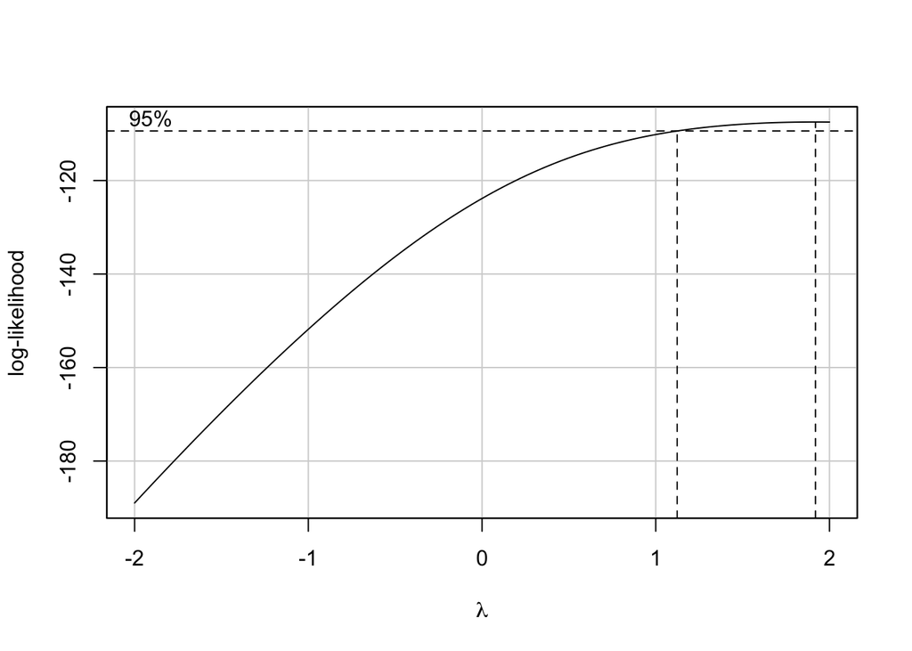

```r
boxCox(results)
```

##### Assumptions

$$H_0: \beta_1 = 0$$

$$H_a: \beta_1 \neq 0$$

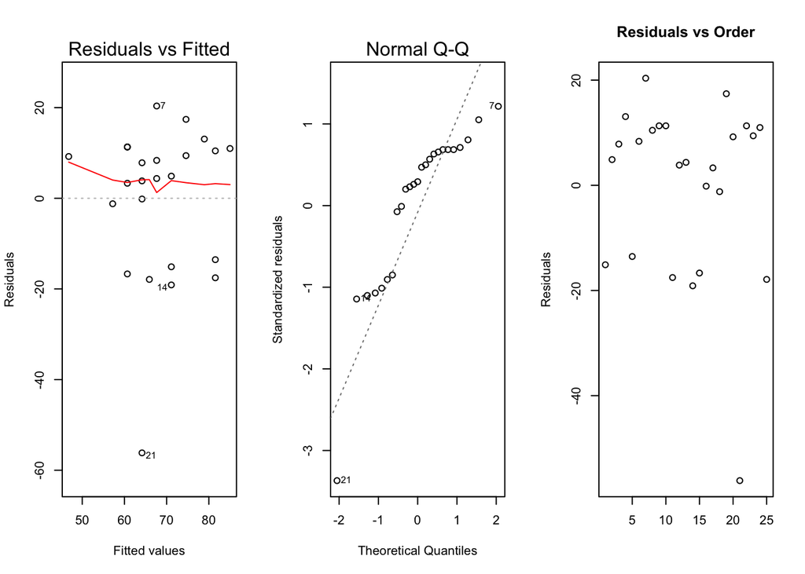

```r
par(mfrow=c(1,3))
plot(results, which=1:2)
plot(results$residuals, main="Residuals vs Order", xlab="",
     ylab="Residuals")
```

- There appear to be some major outliers such as point 21 where the student got a 68% on the midterm, yet only received 8% on the final. It is possible this is an error or that the student stopped going to class and merely guessed on the final.
- One data point was removed from the dataset because they received zeros on both the final and midterm. This is assumed to be a student who dropped the class before the midterm and took neither of the tests.
- The data seems to have constant variance, however, the qq-plot is abnormal, suggesting that the distribution is not quite normal.